This is a report for the first peer assessment of the course Reproducible Research. The contents are written according to the order in the instruction for the assessment.

## Loading and preprocessing the data

First change the working directory to where you put the data file for this project and then use the following code the read the data. Further data processing are being done within each step.

```r
data = read.csv("activity.csv", header = TRUE)
```

## What is the mean total number of steps taken per day?

Now plot a histogram of the total number of steps taken each day and calculate the mean and median of that.

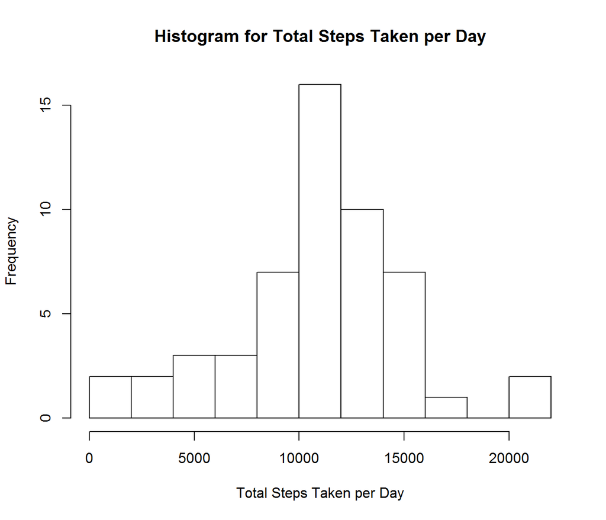

```r
totalsteps = sapply(split(data[,1], data[,2]), sum)
mean_steps = mean(totalsteps, na.rm = TRUE)
median_steps = median(totalsteps, na.rm = TRUE)
hist(totalsteps, breaks = 10, main="Histogram for Total Steps Taken per Day", xlab="Total Steps Taken per Day")
```

The mean and median total number of steps taken per day are 1.076618910^{4} and 10765, respectively.

## What is the daily activity pattern?

First calculate the average number of steps taken for each interval (without missing values) and then make the plot.

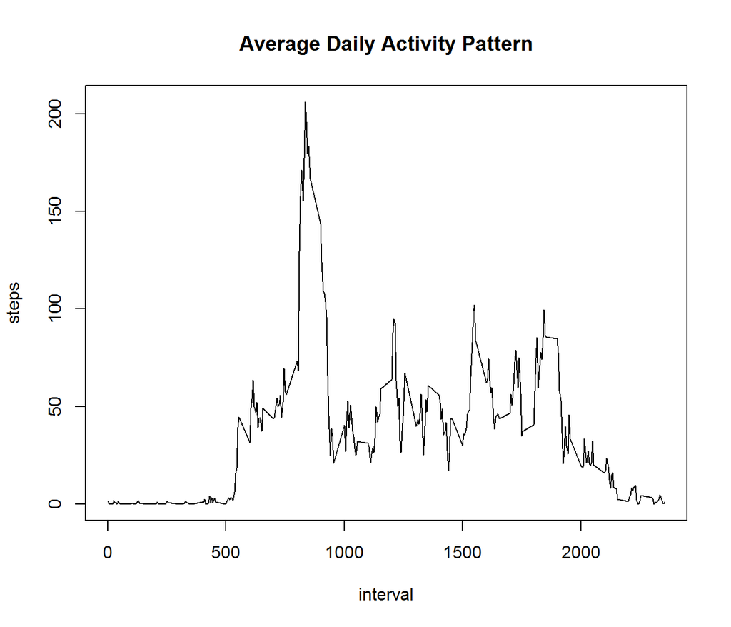

```r
intervalsteps = sapply(split(data[,1], data[,3]), mean, na.rm = TRUE)
intervalsteps = data.frame(interval=as.numeric(names(intervalsteps)), steps=intervalsteps)
maxinterval = intervalsteps[intervalsteps$steps==max(intervalsteps$steps),]
plot(intervalsteps, type="l", main="Average Daily Activity Pattern")
```

Interval 835 contains the maximum number of steps, which is 206.1698113.

## Imputing missing values

First find the index for missing values and replace those values with the mean of that interval. Then we save this new data set in an object named **newdata**. After this, make the histogram again and get the mean and median value.

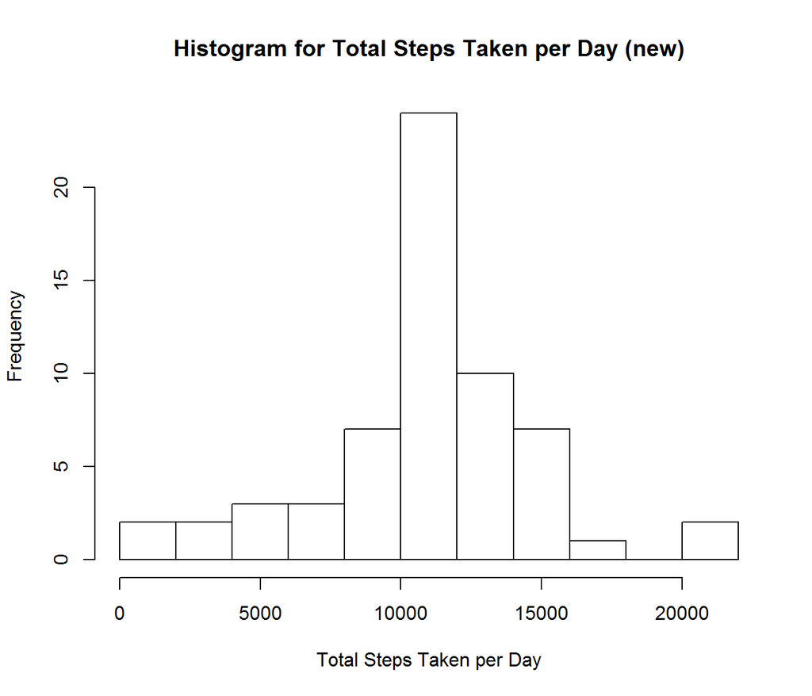

```r
newdata <- data
replace <- cbind(newdata$interval[is.na(newdata$steps)], 0)
for(i in 1:nrow(replace)){
  interval <- replace[i,1]
  temp <- intervalsteps[intervalsteps$interval==interval,"steps"]
  replace[i,2] <- temp
}
newdata$steps[is.na(newdata$steps)] <- replace[,2]

newtotalsteps <- sapply(split(newdata[,1], newdata[,2]), sum)
newmean_steps <- mean(newtotalsteps, na.rm = TRUE)
newmedian_steps <- median(newtotalsteps, na.rm = TRUE)
hist(newtotalsteps, breaks = 10, main="Histogram for Total Steps Taken per Day (new)", xlab="Total Steps Taken per Day")
```

After filling in missing values, the new mean and median values are 1.076618910^{4} and 1.076618910^{4}, respectively. Since we use the mean value of each interval to fill in the missing values, the mean value does not change while the median value is bigger than before.

## Are there differences in activity patterns between weekdays and weekends?

Create a new column for the new factor *weekday*. Then calculate the average number of steps taken for both weekdays and weekends. Finally make the plot.

```r
# Make sure it is in English:)
Sys.setlocale("LC_TIME", "English")
```

```
## [1] "English_United States.1252"
```

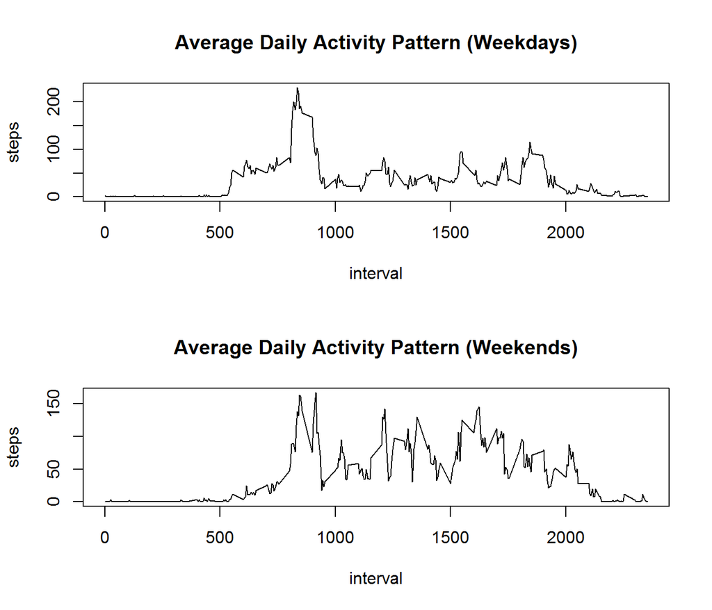

```r
weekend <- c("Saturday", "Sunday")
weekday <- c()
for(i in 1:nrow(newdata)){
  if(weekdays(as.Date(newdata$date[i])) %in% weekend){
    weekday[i] <- "weekend"
  }else weekday[i] <- "weekday"
}
newdata$weekday <- weekday

weekdaydata <- newdata[newdata$weekday=="weekday",]
weekenddata <- newdata[newdata$weekday=="weekend",]
weekdaysteps = sapply(split(weekdaydata[,1], weekdaydata[,3]), mean, na.rm = TRUE)
weekdaysteps = data.frame(interval=as.numeric(names(weekdaysteps)), steps=weekdaysteps)
weekendsteps = sapply(split(weekenddata[,1], weekenddata[,3]), mean, na.rm = TRUE)
weekendsteps = data.frame(interval=as.numeric(names(weekendsteps)), steps=weekendsteps)

par(mfrow=c(2,1))
plot(weekdaysteps, type="l", main="Average Daily Activity Pattern (Weekdays)")
plot(weekendsteps, type="l", main="Average Daily Activity Pattern (Weekends)")
```